# Impact Analysis of Fare-Free Public Transportation Programs

Trabalho de Conclusão de Curso

[Rafael de Acypreste](https://rafaeldeacypreste.github.io/)

Estudante

Thais Carvalho

Orientadora

**Tarifa Zero**

É um modelo de financiamento do transporte público coletivo que é financiado por outras fontes de receita, como impostos, taxas e pedágios, em vez de tarifas pagas pelos(as) passageiros(as).

[figure not shown]

[108 municípios em maio de 2024](https://x.com/_danielsantini/status/1790749556650528832)

[figure not shown]

Formosa (2021)

[figure not shown]

Maricá-RJ (2014)

Luziânia-GO (2023)

[figure not shown]

## Motivação e objetivo

- Impacto na arrecadação: trata-se de uma política que pode ser custosa ao Município;
- Avaliação causal: como não é possível fazer experimentos, é necessário utilizar métodos de avaliação causal para estudos observacionais; e
- Objetivo geral: avaliar o impacto da política de Tarifa-Zero na arrecadação tributária municipal do Imposto sobre Serviços.

## Inferência causal

**O problema da inferência causal: contrafactual**

O que teria acontecido ao Município se não tivesse implementado a Tarifa-Zero?

Alternativas: Angrist and Pischke (2009), Pearl and Mackenzie (2018), Callaway and Sant’Anna (2021), Roth et al. (2023)

Resultados potenciais:

$$\begin{equation} \label{eq-outcome-variable}
Y_{i,t} = D_{i,t} \cdot Y_{i,t}(1) + (1 - D_{i,t}) \cdot Y_{i,t}(0)
\end{equation}$$

Efeito médio do tratamento nos tratados:
$$\begin{equation}
\label{eq-counterfactual}
\tau_2 = \mathbb{E}[Y_{i,2}(1) - Y_{i,2}(0) | D_{i,2} = 1]
\end{equation}$$

## Viés de seleção e variáveis confundidoras

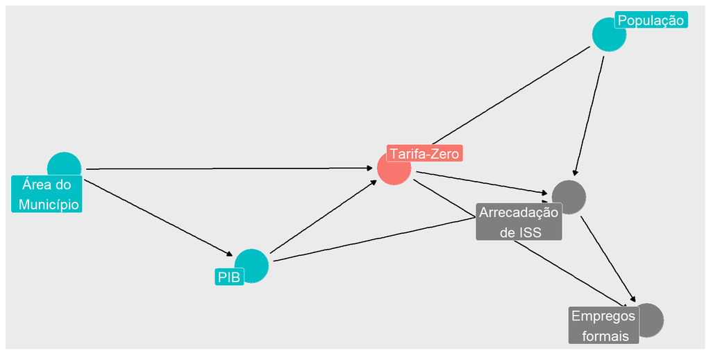

## Viés de seleção (tratado no Grafo)

Viés de seleção ocorre quando a decisão de adoção do tratamento $D_{i,t}$ não é aleatória e há, portanto, co-variáveis que influenciam os valores observados.

$$\begin{equation}
\begin{split}
\tau_2 = \quad & \mathbb{E}[Y_{i,2}(1)| D_{i,2} = 1] - \mathbb{E}[Y_{i,2}(0) | D_{i,2} = 0] \\
& + \underbrace{\mathbb{E}[Y_{i,2}(0) | D_{i,2} = 0] - \mathbb{E}[Y_{i,2}(0) | D_{i,2} = 1]}_{\text{viés de seleção}}
\end{split}
\end{equation}$$

## Variáveis de interesse (fontes)

- Santini (2024): lista de municípios que adotaram o Tarifa-Zero;
- IPEA: dados de arrecadação tributária municipal; e
- IBGE: variáveis socioeconômicas: PIB, população e tamanho dos municípios.

Há outras variáveis coletadas, mas que não foram utilizadas no trabalho, como dados de emprego, mortalidade no trânsito e frota de veículos.

## Diferenças-em-Diferenças (DiD)

Consiste em tomar a diferença entre a média do tratamento e do controle antes e depois da implementação da política e, depois, subtrair essas diferenças.

[figure not shown]

$$\begin{equation} \label{eq-did-estimator}
\begin{split}
\tau_2 & = \mathbb{E}[Y_{i,2}(1) - Y_{i,2}(0) | D_{i,2} = 1] \\
& = \mathbb{E}[Y_{i,2} \color{#FBFF0A}{-} Y_{i,1}| \boldsymbol{X}, D_{i,2} = 1] \color{#FBFF0A}{-} \mathbb{E}[Y_{i,2} \color{#FBFF0A}{-} Y_{i,1} | \boldsymbol{X}, D_{i,2} = 0].
\end{split}
\end{equation}$$

## Estimador DiD duplamente robusto

Trata-se de uma extensão do estimador DiD que permite a inclusão de covariáveis e exige que apenas um dos modelos de regressão seja corretamente especificado.

$$\begin{equation}
\label{eq-dr-identification}
ATT(g, t) = \mathbb{E} \left[ \left(\frac{G_g}{\mathbb{E}[G_g]} - \dfrac{ \dfrac{p_g(\boldsymbol{X}) C}{1 - p_g(\boldsymbol{X})} }{\mathbb{E} \left[\dfrac{p_g(\boldsymbol{X}) C}{1 - p_g(\boldsymbol{X})} \right]} \right) (Y_t - Y_{g-1} - m_{g,t}(\boldsymbol{X}) ) \right].
\end{equation}$$

## Método

- As variáveis foram coletadas de 2003 a 2019 e avaliadas em escala logarítmica, dada a elevada heterogeneidade dos minicípios;
- Utilizou-se o modelo de diferenças-em-diferenças duplamente robusto com covariáveis;
- A aplicação dos modelos e os gráficos de resultados foram realizadas com o pacote `DiD` (linguagem R);
- Como a quantidade de municípios em cada grupo é reduzido, foram analisados apenas resultados agregados; e
- A análise de sensibilidade foi realizada com o auxílio do pacote `DRDID` (linguagem R).

## Análise Exploratória

[figure not shown]

## Principais resultados

[figure not shown]

## Análise de sensibilidade dos resultados

- Foram testados modelos sem covariáveis e modelos com outros conjuntos de covariáveis, sem alteração significativa dos resultados;
- Foi realizado um estudo de evento e, ao menos antes de receber o tratamento, os municípios pareciam seguir tendências paralelas;
- Não foram encontradas evidências de que os pressupostos do modelo foram violados.

## Discussão

- O efeito médio sobre os tratados a partir da agregação por grupos foi de [3,6%; 16,6%], com confiança de 95%;
- Já o efeito dinâmico para o conjunto de municípios com, no mínimo 5 anos de adoção foi de [0,2%; 30,4%], também com confiança de 95%; e
- As demais métricas também indicaram efeitos médios positivos sobre os tratados.

## Conclusões

- Os dados oferecem suporte à hipótese de que a Tarifa-Zero tem impacto positivo na arrecadação tributária municipal;
- Entretanto, os resultados devem ser interpretados com cautela, dado o pequeno número de municípios que adotaram a política; e
- Em especial, as razões para a adoção da Tarifa-Zero podem ser diferentes entre os municípios, o que pode influenciar os resultados. Portanto, devem ser avaliadas em estudos futuros.

# Referências

Angrist, Joshua D., and Jörn-Steffen Pischke. 2009. *Mostly Harmless Econometrics: An Empiricist’s Companion*. Princeton University Press. http://www.jstor.org/stable/j.ctvcm4j72.

Callaway, Brantly, and Pedro H. C. Sant’Anna. 2021. “Difference-in-Differences with Multiple Time Periods.” *Journal of Econometrics* 225 (2): 200–230. https://doi.org/https://doi.org/10.1016/j.jeconom.2020.12.001.

Pearl, Judea, and Dana Mackenzie. 2018. *The Book of Why: The New Science of Cause and Effect*. Basic Books.

Roth, Jonathan, Pedro H. C. Sant’Anna, Alyssa Bilinski, and John Poe. 2023. “What’s Trending in Difference-in-Differences? A Synthesis of the Recent Econometrics Literature.” *Journal of Econometrics* 235 (2): 2218–44. https://doi.org/10.1016/j.jeconom.2023.03.008.

Santini, Daniel. 2024. “Brazilian municipalities with full Fare-Free Public Transport policies - updated March 2024.” Version V1. Harvard Dataverse. https://doi.org/10.7910/DVN/Z927PD.